# Prediction Assignment Writeup

L. Boshuizen

## Summary

Human Activity Recognition - HAR - has emerged as a key research area in the last years and is gaining increasing attention by the pervasive computing research. This HAR research has traditionally focused on discriminating between different activities, i.e. to predict “which” activity was performed at a specific point in time. The Weight Lifting Exercises dataset used in this study was collected to investigate “how (well)” an activity was performed by the wearer. The data is collected from accelerometers on the belt, forearm, arm, and dumbell of 6 participants.

The goal of this project is to predict the manner in which the participant in the study did the exercise. This is the “classe” variable in the training set.

3 Models are trained on the training set and combined into an ensemble:

1. Random Forest
2. Gradient Boost
3. Linear discriminant analysis

```r
library(caret)
library(dplyr)
library(reshape2)
library(ggplot2)
library(readr)
library(randomForest)

set.seed(42)
```

## Exploration

### Data transformation

I took a different approach by investigating on wich variables a prediction should be made:

As it makes no sense to predict on vars that are NA, drop all vars from the test-set that are NA. To be able to create a reliable model that can predict on the test-set, ONLY the variables that *remained* in the *testset* were *retained* in the *trainingset*. **All others are dropped.**

```r
df_train <- read_csv('./data/pml-training.csv')
```

[output not shown]

```r
df_test <- read_csv('./data/pml-testing.csv')
df_train <- df_train[,-1]
df_test <- df_test[,-1]

retain <- names(df_test)[colSums(!is.na(df_test)) > 0]
df_test <- df_test[, retain]
train_retain <- names(df_train) %in% retain
classe <- factor(df_train$classe)
df_train <- df_train[, train_retain]
df_train <- cbind(classe,df_train)

df_train$cvtd_timestamp <- NULL
df_train$new_window <- factor(df_train$new_window)

str(df_train)
```

```
'data.frame':   19622 obs. of  58 variables:
 $ classe              : Factor w/ 5 levels "A","B","C","D",..: 1 1 1 1 1 1 1 1 1 1 ...
 $ user_name           : chr  "carlitos" "carlitos" "carlitos" "carlitos" ...
 $ raw_timestamp_part_1: num  1.32e+09 1.32e+09 1.32e+09 1.32e+09 1.32e+09 ...
 $ raw_timestamp_part_2: num  788290 808298 820366 120339 196328 ...
 $ new_window          : Factor w/ 2 levels "no","yes": 1 1 1 1 1 1 1 1 1 1 ...
 $ num_window          : num  11 11 11 12 12 12 12 12 12 12 ...
 $ roll_belt           : num  1.41 1.41 1.42 1.48 1.48 1.45 1.42 1.42 1.43 1.45 ...
 $ pitch_belt          : num  8.07 8.07 8.07 8.05 8.07 8.06 8.09 8.13 8.16 8.17 ...
 $ yaw_belt            : num  -94.4 -94.4 -94.4 -94.4 -94.4 -94.4 -94.4 -94.4 -94.4 -94.4 ...
 $ total_accel_belt    : num  3 3 3 3 3 3 3 3 3 3 ...
 $ gyros_belt_x        : num  0 0.02 0 0.02 0.02 0.02 0.02 0.02 0.02 0.03 ...
 $ gyros_belt_y        : num  0 0 0 0 0.02 0 0 0 0 0 ...
 $ gyros_belt_z        : num  -0.02 -0.02 -0.02 -0.03 -0.02 -0.02 -0.02 -0.02 -0.02 0 ...
 $ accel_belt_x        : num  -21 -22 -20 -22 -21 -21 -22 -22 -20 -21 ...
```

[output cut: 44 more lines]

### Correlation

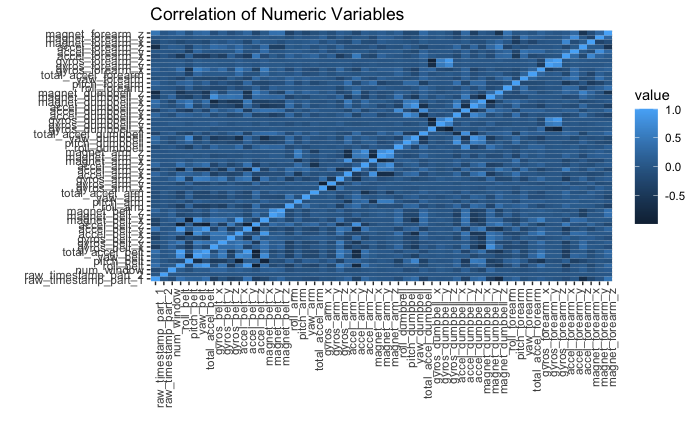

```r
nums <- sapply(df_train, is.numeric)
num_df <- df_train[nums]
corMat <- cor(num_df)
melted_cormat <- melt(corMat)
ggplot(data = melted_cormat, aes(x=Var1, y=Var2, fill=value)) +
    geom_tile() + theme(axis.text.x = element_text(angle = 90, hjust = 1))+labs(x = "", y="", title="Correlation of Numeric Variables")
```

## Modeling

3 Models are trained on 80% of the training set and each evaluated on the remaining 20% of the training set.

1. Random Forest
2. Grandient Boost
3. Linear discriminant analysis

Those 3 are then combined into a 4th ensemble model.

```r
ix_train <- createDataPartition(df_train$classe, p=.8, list=F)
train_set <- df_train[ix_train,]
test_set <- df_train[-ix_train,]
```

### Random forest (RF)

```r
m_rf <- randomForest(classe ~ ., data = train_set, importance = T)
p_rf <- predict(m_rf, test_set)
cfm_rf <- confusionMatrix(p_rf, test_set$classe)
cfm_rf
```

```
Confusion Matrix and Statistics

          Reference
Prediction    A    B    C    D    E
         A 1116    0    0    0    0
         B    0  759    0    0    0
         C    0    0  684    1    0
         D    0    0    0  642    0
         E    0    0    0    0  721

Overall Statistics

               Accuracy : 0.9997
                 95% CI : (0.9986, 1)
    No Information Rate : 0.2845
    P-Value [Acc > NIR] : < 2.2e-16

                  Kappa : 0.9997

 Mcnemar's Test P-Value : NA

Statistics by Class:

                     Class: A Class: B Class: C Class: D Class: E
Sensitivity            1.0000   1.0000   1.0000   0.9984   1.0000
Specificity            1.0000   1.0000   0.9997   1.0000   1.0000
Pos Pred Value         1.0000   1.0000   0.9985   1.0000   1.0000
Neg Pred Value         1.0000   1.0000   1.0000   0.9997   1.0000
Prevalence             0.2845   0.1935   0.1744   0.1639   0.1838
Detection Rate         0.2845   0.1935   0.1744   0.1637   0.1838
Detection Prevalence   0.2845   0.1935   0.1746   0.1637   0.1838
Balanced Accuracy      1.0000   1.0000   0.9998   0.9992   1.0000
```

### Gradient Boosting (GBM)

```r
m_bt <- train(classe ~ ., data = train_set,method="gbm", verbose=F)
p_gbm <- predict(m_bt, newdata = test_set)
cfm_gbm <- confusionMatrix(p_gbm,test_set$classe)
cfm_gbm
```

```
Confusion Matrix and Statistics

          Reference
Prediction    A    B    C    D    E
         A 1116    1    0    0    0
         B    0  756    0    0    0
         C    0    2  681    0    0
         D    0    0    3  639    0
         E    0    0    0    4  721

Overall Statistics

               Accuracy : 0.9975
                 95% CI : (0.9953, 0.9988)
    No Information Rate : 0.2845
    P-Value [Acc > NIR] : < 2.2e-16

                  Kappa : 0.9968

 Mcnemar's Test P-Value : NA

Statistics by Class:

                     Class: A Class: B Class: C Class: D Class: E
Sensitivity            1.0000   0.9960   0.9956   0.9938   1.0000
Specificity            0.9996   1.0000   0.9994   0.9991   0.9988
Pos Pred Value         0.9991   1.0000   0.9971   0.9953   0.9945
Neg Pred Value         1.0000   0.9991   0.9991   0.9988   1.0000
Prevalence             0.2845   0.1935   0.1744   0.1639   0.1838
Detection Rate         0.2845   0.1927   0.1736   0.1629   0.1838
Detection Prevalence   0.2847   0.1927   0.1741   0.1637   0.1848
Balanced Accuracy      0.9998   0.9980   0.9975   0.9964   0.9994
```

### Linear discriminant analysis (LDA)

```r
m_lda <- train(classe ~ ., data = train_set,method="lda")
p_lda <- predict(m_lda, newdata = test_set)
cfm_lda <- confusionMatrix(p_lda,test_set$classe)
cfm_lda
```

```
Confusion Matrix and Statistics

          Reference
Prediction   A   B   C   D   E
         A 963 101  57  40  29
         B  30 502  62  25  92
         C  59 101 489  73  59
         D  64  28  72 496  56
         E   0  27   4   9 485

Overall Statistics

               Accuracy : 0.7482
                 95% CI : (0.7343, 0.7617)
    No Information Rate : 0.2845
    P-Value [Acc > NIR] : < 2.2e-16

                  Kappa : 0.681

 Mcnemar's Test P-Value : < 2.2e-16

Statistics by Class:

                     Class: A Class: B Class: C Class: D Class: E
Sensitivity            0.8629   0.6614   0.7149   0.7714   0.6727
Specificity            0.9191   0.9339   0.9098   0.9329   0.9875
Pos Pred Value         0.8092   0.7060   0.6261   0.6927   0.9238
Neg Pred Value         0.9440   0.9200   0.9379   0.9542   0.9305
Prevalence             0.2845   0.1935   0.1744   0.1639   0.1838
Detection Rate         0.2455   0.1280   0.1246   0.1264   0.1236
Detection Prevalence   0.3033   0.1812   0.1991   0.1825   0.1338
Balanced Accuracy      0.8910   0.7977   0.8124   0.8522   0.8301
```

### Ensemble

```r
df_c <- data.frame(rf=p_rf,gbm=p_gbm,lda=p_lda,classe=test_set$classe)
m_c <- train(classe ~ ., data=df_c, method="rf")
p_c <- predict(m_c, newdata = df_c)
cfm_ens <- confusionMatrix(p_c,test_set$classe)
cfm_ens
```

```
Confusion Matrix and Statistics

          Reference
Prediction    A    B    C    D    E
         A 1116    0    0    0    0
         B    0  759    0    0    0
         C    0    0  684    1    0
         D    0    0    0  642    0
         E    0    0    0    0  721

Overall Statistics

               Accuracy : 0.9997
                 95% CI : (0.9986, 1)
    No Information Rate : 0.2845
    P-Value [Acc > NIR] : < 2.2e-16

                  Kappa : 0.9997

 Mcnemar's Test P-Value : NA

Statistics by Class:

                     Class: A Class: B Class: C Class: D Class: E
Sensitivity            1.0000   1.0000   1.0000   0.9984   1.0000
Specificity            1.0000   1.0000   0.9997   1.0000   1.0000
Pos Pred Value         1.0000   1.0000   0.9985   1.0000   1.0000
Neg Pred Value         1.0000   1.0000   1.0000   0.9997   1.0000
Prevalence             0.2845   0.1935   0.1744   0.1639   0.1838
Detection Rate         0.2845   0.1935   0.1744   0.1637   0.1838
Detection Prevalence   0.2845   0.1935   0.1746   0.1637   0.1838
Balanced Accuracy      1.0000   1.0000   0.9998   0.9992   1.0000
```

## Results

A table with the collected results:

| Model | Accuracy | 95% Conf. Interval |  |
| --- | --- | --- | --- |
| Random forest | 0.9997451 | 0.9985806 | 0.9999935 |
| GBM | 0.9974509 | 0.9953172 | 0.998777 |
| LDA | 0.7481519 | 0.7342595 | 0.7616738 |
| Ensemble | 0.9997451 | 0.9985806 | 0.9999935 |

Random forest & Gradient Boost already have an high accuracy, LDA lagging behind.

Combining the models into an ensemble results in a model the same performance as RF.